**Logistic Regression**

|  | by Seungchul Lee iSystems Design Lab http://isystems.unist.ac.kr/ UNIST |
| --- | --- |

Table of Contents

# 1. Linear Classification: Logistic Regression

## 1.1. Using all Distances

- Logistic regression is a classification algorithm - don't be confused
- Perceptron: make use of sign of data
- SVM: make use of margin (minimum distance)
- We want to use *distance information of all data points* $\rightarrow$ logistic regression

[figure not shown]

- basic idea: find the decision boundary (hyperplane) of $g(x)=\omega^T x =0$ such that maximizes $\prod_i \lvert h_i \rvert$
  - Inequality of arithmetic and geometric means $$ \frac{h_1+h_2}{2} \geq \sqrt{h_1 h_2} $$ and that equality holds if and only if $h_1 = h_2$
- Roughly speaking, this optimization of $\max \prod_i \lvert h_i \rvert$ tends to position a hyperplane in the middle of two classes

$$h = \frac{g(x)}{\lVert \omega \rVert} = \frac{\omega^T x}{\lVert \omega \rVert} \approx \omega^T x$$

- We link or squeeze $(-\infty, +\infty)$ to $(0,1)$ for several reasons:

[figure not shown]

```python
import numpy as np
import matplotlib.pyplot as plt
from cvxpy import *
from numpy.random import rand
from numpy.linalg import inv
from mpl_toolkits.mplot3d import Axes3D

% matplotlib inline
```

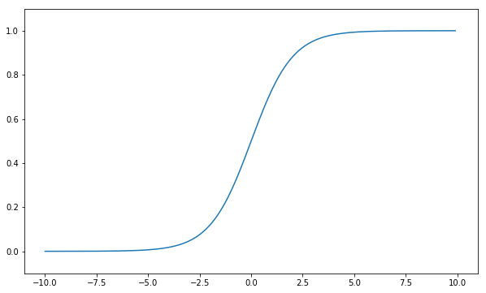

```python
# What does the sigmoid function look like

z = np.arange(-10, 10, 0.1)
s = 1/(1+np.exp(-z))
plt.figure(figsize=(10, 6))
plt.plot(z, s)
plt.xlim(-11, 11)
plt.ylim(-0.1, 1.1)
plt.show()
```

- Benefit of mapping via the logistic function
  - monotonic: same or similar optimziation solution
  - continuous and differentiable: good for gradient descent optimization
  - probability or confidence: can be considered as probability

  $$P\left(y = +1 \mid x,\omega\right) = \frac{1}{1+e^{-\omega^T x}} \in [0,1]$$
  - Often we do note care about predicting the label $y$ for an example
  - Rather, we want to predict the label probabilities $P\left(y \mid x,\omega\right)$
    - $P\left(y = +1 \mid x,\omega\right)$: the probability that the label is $+1$
    - $P\left(y = 0 \mid x,\omega\right) = 1 - P\left(y = +1 \mid x,\omega\right)$: the probability that the label is $0$
    - In a sense, it is our confidence in the predicted label
- Goal: we need to fit $\omega$ to our data

## 1.2. Probabilistic Approach (or MLE)

Consider a random variable $ y \in \{0, 1\} $

$$P(y=+1) = p, \quad P(y=0) = 1-p$$

where $ p \in [0, 1]$, and is assumed to depend on a vector of explanatory variables $x \in \mathbb{R}^n$

the logistic model has the form

$$ \begin{align*} p &= \frac{1}{1+e^{-\omega^T x}} = \frac{e^{\omega^T x}}{e^{\omega^T x} + 1}\\ 1-p &= \frac{1}{e^{\omega^T x} + 1} \end{align*} $$

We can re-order the data so far $x_1, \cdots, x_q$, the outcome is $y = +1$, and for $x_{q+1}, \cdots, x_m$, the outcome is $y=0$

The likelihood function

$$\mathscr{L} = \prod\limits_{i=1}^{q}{p_i}\prod\limits_{i=q+1}^{m}{(1-p_i)} \qquad \left(\sim \prod_i \lvert h_i \rvert \right)$$

the log likelihood function

$$ \begin{align*} \mathscr{l}(\omega) &= \log \mathscr{L} = \sum\limits_{i=1}^{q}{\log p_i} + \sum\limits_{i=q+1}^{m}{\log(1 - p_i)} \\ & = \sum\limits_{i=1}^{q}{\log \frac{\exp\left(\omega^T x_i\right)}{1 + \exp \left(\omega^T x_i \right)}} + \sum\limits_{i=q+1}^{m}{\log \frac{1}{1+\exp \left(\omega^T x_i \right)}} \\ &= \sum\limits_{i=1}^{q}{\left(\omega^T x_i\right)} - \sum\limits_{i=1}^{m}{\log \left(1+\exp \left(\omega^T x_i \right) \right)} \end{align*} $$

Since $\mathscr{l}$ is a concave function of $\omega$, the logistic regression problem can be solved as a convex optimization problem

$$\hat{\omega} = \arg\max_{\omega} \mathscr{l}(\omega)$$

## 1.3. Example with CVX

$$ \begin{align*} \omega &= \begin{bmatrix} \omega_1 \\ \omega_2 \\ \omega_3\end{bmatrix}, \quad x = \begin{bmatrix} x_1 \\ x_2 \\ 1\end{bmatrix}\\ X &= \begin{bmatrix} \left(x^{(1)}\right)^T \\ \left(x^{(2)}\right)^T \\ \left(x^{(3)}\right)^T \\ \vdots\end{bmatrix} = \begin{bmatrix} x_1^{(1)} & x_2^{(1)} & 1 \\x_1^{(2)} & x_2^{(2)} & 1 \\x_1^{(3)} & x_2^{(3)} & 1 \\ \vdots & \vdots & \vdots \\\end{bmatrix} \end{align*} $$

Source: Section 7.1.1 from http://cvxr.com/cvx/examples/cvxbook/Ch07_statistical_estim/html/logistics.html

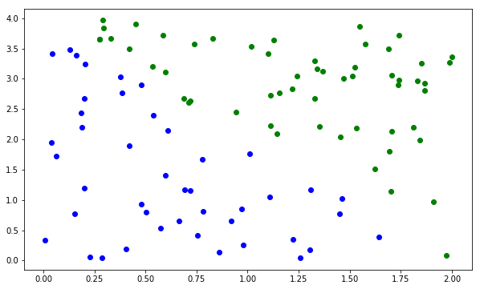

```python
# Boyd & Vandenberghe, "Convex Optimization"
# Original by Lieven Vandenberghe
# Adapted for CVX by Argyris Zymnis - 01/31/06

# Generate data

m = 100
w = np.array([2, 1, -4]).reshape(-1, 1)

X = np.hstack([2*rand(m, 1), 4*rand(m, 1), np.ones([m, 1])])
X = np.asmatrix(X)

y = (0.5 < np.exp(X*w)/(1.0+np.exp(X*w))).astype('int')

c1 = np.where(y == 1)[0]
c2 = np.where(y == 0)[0]

plt.figure(figsize=(10, 6))
plt.plot(X[c1,0], X[c1,1], 'go')
plt.plot(X[c2,0], X[c2,1], 'bo')
plt.show()
```

$$ \begin{align*} \mathscr{l}(\omega) &= \log \mathscr{L} = \sum\limits_{i=1}^{q}{\log p_i} + \sum\limits_{i=q+1}^{m}{\log(1 - p_i)} \\ & = \sum\limits_{i=1}^{q}{\log \frac{\exp\left(\omega^T x_i\right)}{1 + \exp \left(\omega^T x_i \right)}} + \sum\limits_{i=q+1}^{m}{\log \frac{1}{1+\exp \left(\omega^T x_i \right)}} \\ &= \sum\limits_{i=1}^{q}{\left(\omega^T x_i\right)} - \sum\limits_{i=1}^{m}{\log \left(1+\exp \left(\omega^T x_i \right) \right)} \end{align*} $$

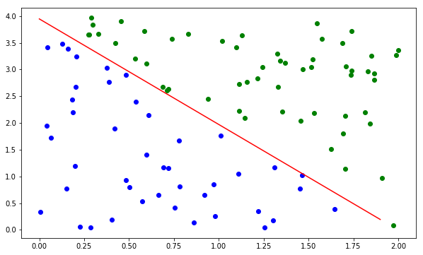

```python
w = Variable(3, 1)

objective = Maximize(y.T*X*w - sum_entries(logistic(X*w)))
prob = Problem(objective)
result = prob.solve(solver='SCS')

w = w.value

xp = np.arange(0, 2, 0.1)
yp = (-w[0,0]*xp-w[2,0])/w[1,0]

plt.figure(figsize=(10, 6))
plt.plot(X[c1,0], X[c1,1], 'go')
plt.plot(X[c2,0], X[c2,1], 'bo')
plt.plot(xp, yp, 'r')
plt.show()
```

```python
% matplotlib qt
```

```python
% matplotlib inline
```

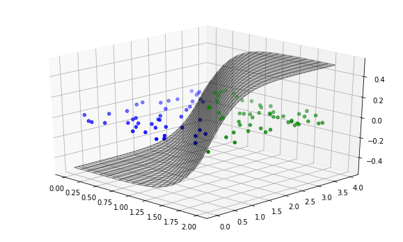

```python
X1, X2 = np.meshgrid(np.arange(0, 2, 0.1), np.arange(0, 4, 0.1))

w = w/np.linalg.norm(w, 2)*10
Z = np.exp(X1*w[0,0]+X2*w[1,0]+w[2,0])/(1 + np.exp(X1*w[0,0]+X2*w[1,0]+w[2,0])) - 1/2

Xa = np.asarray(X)

fig = plt.figure(figsize=(10, 6))
ax = fig.add_subplot(111, projection='3d')
ax.plot_wireframe(X1, X2, Z, color='k', alpha=0.4)
ax.scatter(Xa[c1,0], Xa[c1,1], np.zeros([c1.shape[0], 1]), c='g')
ax.scatter(Xa[c2,0], Xa[c2,1], np.zeros([c2.shape[0], 1]), c='b')
ax.view_init(25, -45)
plt.show()
```

**In a more compact form**

Change $y \in \{0,+1\} \rightarrow y \in \{-1,+1\}$ for compuational convenience

- Consider the following function

$$P\left(y \mid x,\omega\right) = \sigma\left(y\omega^Tx\right) = \frac{1}{1+\exp\left(-y\omega^T x\right)} \in [0,1]$$

- Log-likelihood

$$ \begin{align*} \mathscr{l}(\omega) = \log \mathscr{L} = \log P\left(y \mid x,\omega\right)& = \log \prod_{n=1}^{m} P\left(y_n \mid x_n,\omega\right)\\ &= \sum_{n=1}^{m} \log P\left(y_n \mid x_n,\omega\right)\\ &= \sum_{n=1}^{m} \log \frac{1}{1+\exp\left(-y_n\omega^T x_n\right)}\\ &= \sum\limits_{n=1}^{m}{-\log \left(1+\exp \left(-y_n\omega^T x_n \right) \right)} \end{align*} $$

- MLE solution

$$ \begin{align*} \hat{\omega} &= \arg \max_{\omega} \sum\limits_{n=1}^{m}{-\log \left(1+\exp \left(-y_n\omega^T x_n \right) \right)}\\ &= \arg \min_{\omega} \sum\limits_{n=1}^{m}{\log \left(1+\exp \left(-y_n\omega^T x_n \right) \right)} \end{align*} $$

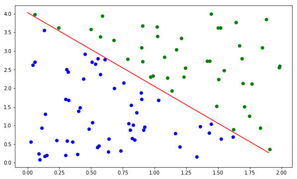

```python
yc = y.copy()
yc[yc == 0] = -1

w = Variable(3, 1)

objective = Minimize(sum_entries(logistic(mul_elemwise(-yc, X*w))))
prob = Problem(objective)
result = prob.solve(solver='SCS')

w = w.value

xp = np.arange(0, 2, 0.1)
yp = (-w[0,0]*xp - w[2,0])/w[1,0]

plt.figure(figsize=(10, 6))
plt.plot(X[c1,0], X[c1,1], 'go')
plt.plot(X[c2,0], X[c2,1], 'bo')
plt.plot(xp, yp, 'r')
plt.show()
```

## 1.4. Logistic Regression with Gradient Descent (Optional)

- Logistic regression $$ \begin{align*} J(\omega) = \sum\limits_{n=1}^{m}{\log \left(1+\exp \left(-y_n\omega^T x_n \right) \right)} \end{align*} $$
- Gradient and Hessian given by: $$ \begin{align*} \nabla_{\omega}J(\omega) &= -X^T Z y\\ \nabla_{\omega}^2J(\omega) &= X^T Z(I-Z) X\\ \end{align*} $$ where $$Z \in \mathbb{R}^{m\times m}, \qquad Z_{nn} = \frac{1}{1+\exp \left(-y_n\omega^T x_n \right) }$$
- See how fast it is in terms of computional time

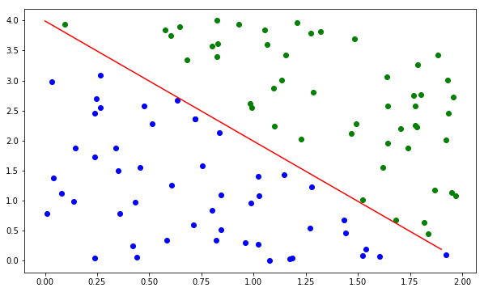

```python
# logistic regression using gradient descent

yc = y.copy()
yc[y == 0] = -1

k = X.shape[1]
theta = np.zeros([k, 1])

g = 1

while np.linalg.norm(g) > 1e-10:
    z = 1/(1 + np.exp(np.multiply(y, (X*theta))))
    g = -X.T*np.multiply(z, y)
    H = X.T*np.diag(np.asarray(np.multiply(z, 1-z)).ravel())*X
    theta = theta - inv(H)*g

xp = np.arange(0, 2, 0.1)
yp = (-theta[0,0]*xp - theta[2,0])/theta[1,0]
plt.figure(figsize=(10, 6))
plt.plot(X[c1,0], X[c1,1], 'go')
plt.plot(X[c2,0], X[c2,1], 'bo')
plt.plot(xp, yp, 'r')
plt.show()
```

# 2. Regularized Logistic Regression

- $l_2$ regularized logistic regression
  - make $\omega$ small $$ \begin{align*} \min_{\omega} &\; \lambda \rVert \omega \lVert_2^2 + \sum\limits_{n=1}^{m}{\log \left(1+\exp \left(-y_n\omega^T x_n \right) \right)} \end{align*} $$
- $l_1$ regularized logistic regression
  - make $\omega$ small and sparse $\rightarrow$ feature selection for classification

$$ \begin{align*} \min_{\omega} &\; \lambda \rVert \omega \lVert_1 + \sum\limits_{n=1}^{m}{\log \left(1+\exp \left(-y_n\omega^T x_n \right) \right)} \end{align*} $$

- The effect of regularization will be more clearly illustrated with a non-linear data set

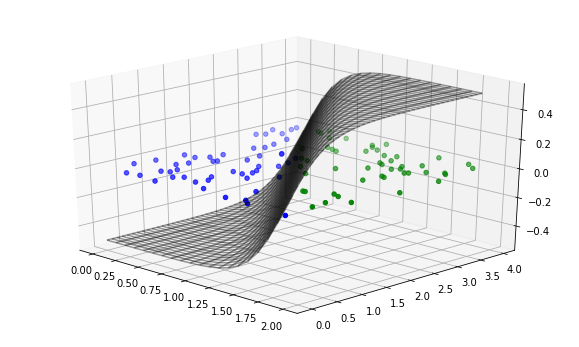

```python
m = 100
w = np.array([2, 1, -4]).reshape(-1, 1)

X = np.hstack([2*rand(m, 1), 4*rand(m, 1), np.ones([m, 1])])
X = np.asmatrix(X)

y = (0.5 < np.exp(X*w)/(1.0+np.exp(X*w))).astype('int')
y[y == 0] = -1

c1 = np.where(y == 1)[0]
c2 = np.where(y == -1)[0]

g = 1

w = Variable(3, 1)

objective = Minimize(g*norm(w, 2) + sum_entries(logistic(mul_elemwise(-y, X*w))))
prob = Problem(objective)
result = prob.solve(solver='SCS')

w = w.value

X1, X2 = np.meshgrid(np.arange(0, 2, 0.1), np.arange(0, 4, 0.1))

Z = np.exp(X1*w[0,0]+X2*w[1,0]+w[2,0])/(1 + np.exp(X1*w[0,0]+X2*w[1,0]+w[2,0])) - 1/2

Xa = np.asarray(X)

fig = plt.figure(figsize=(10, 6))
ax = fig.add_subplot(111, projection='3d')
ax.plot_wireframe(X1, X2, Z, color='k', alpha=0.4)
ax.scatter(Xa[c1,0], Xa[c1,1], np.zeros([c1.shape[0], 1]), c='g')
ax.scatter(Xa[c2,0], Xa[c2,1], np.zeros([c2.shape[0], 1]), c='b')
ax.view_init(25, -45)
plt.show()
```

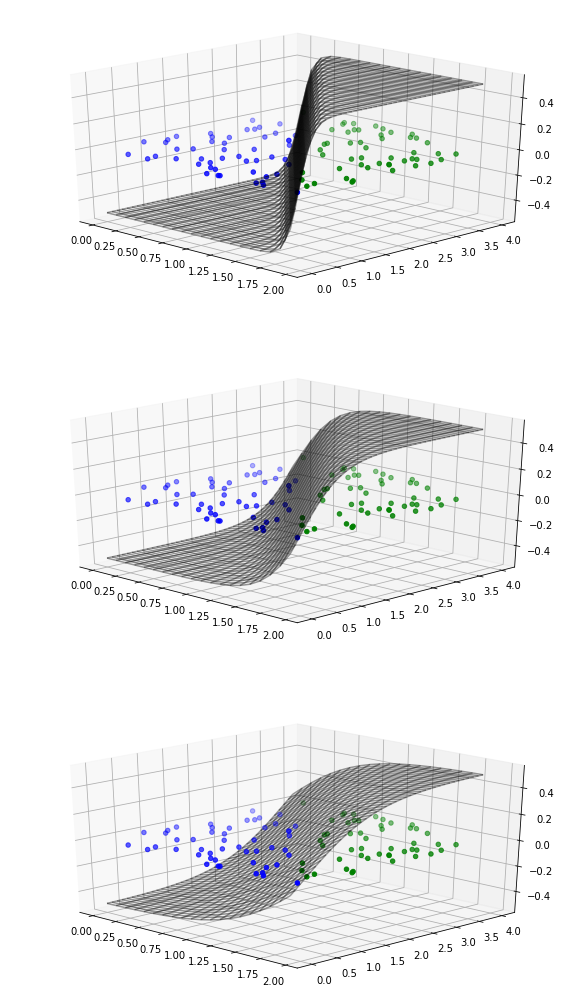

```python
m = 100
w = np.array([2, 1, -4]).reshape(-1, 1)

X = np.hstack([2*rand(m, 1), 4*rand(m, 1), np.ones([m, 1])])
X = np.asmatrix(X)

y = (0.5 < np.exp(X*w)/(1.0+np.exp(X*w))).astype('int')
y[y == 0] = -1

c1 = np.where(y == 1)[0]
c2 = np.where(y == -1)[0]

g = [0.1, 1, 3]

fig = plt.figure(figsize=(10, 18))
for i in range(3):
    w = Variable(3, 1)

    objective = Minimize(g[i]*norm(w, 2) + sum_entries(logistic(mul_elemwise(-y, X*w))))
    prob = Problem(objective)
    result = prob.solve(solver='SCS')

    w = w.value

    X1, X2 = np.meshgrid(np.arange(0, 2, 0.1), np.arange(0, 4, 0.1))

    Z = np.exp(X1*w[0,0]+X2*w[1,0]+w[2,0])/(1 + np.exp(X1*w[0,0]+X2*w[1,0]+w[2,0])) - 1/2

    Xa = np.asarray(X)

    ax = fig.add_subplot(3, 1, i+1, projection='3d')
    ax.plot_wireframe(X1, X2, Z, color='k', alpha=0.4)
    ax.scatter(Xa[c1,0], Xa[c1,1], np.zeros([c1.shape[0], 1]), c='g')
    ax.scatter(Xa[c2,0], Xa[c2,1], np.zeros([c2.shape[0], 1]), c='b')
    ax.view_init(25, -45)

plt.show()
```

- $l_1$ regularized logistic regression
  - make $\omega$ small and sparse $\rightarrow$ feature selection for classification

$$ \begin{align*} \min_{\omega} &\; \lambda \rVert \omega \lVert_1 + \sum\limits_{n=1}^{m}{\log \left(1+\exp \left(-y_n\omega^T x_n \right) \right)} \end{align*} $$

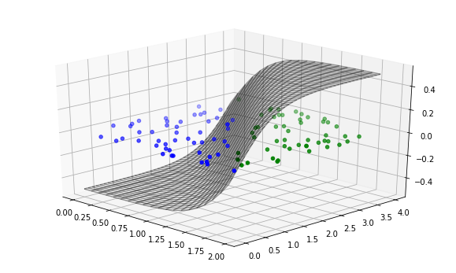

```python
g = 1

w = Variable(3, 1)

objective = Minimize(g*norm(w, 1) + sum_entries(logistic(mul_elemwise(-y, X*w))))
prob = Problem(objective)
result = prob.solve(solver='SCS')

w = w.value

X1, X2 = np.meshgrid(np.arange(0, 2, 0.1), np.arange(0, 4, 0.1))

Z = np.exp(X1*w[0,0]+X2*w[1,0]+w[2,0])/(1 + np.exp(X1*w[0,0]+X2*w[1,0]+w[2,0])) - 1/2

Xa = np.asarray(X)

fig = plt.figure(figsize=(10, 6))
ax = fig.add_subplot(111, projection='3d')
ax.plot_wireframe(X1, X2, Z, color='k', alpha=0.4)
ax.scatter(Xa[c1,0], Xa[c1,1], np.zeros([c1.shape[0], 1]), c='g')
ax.scatter(Xa[c2,0], Xa[c2,1], np.zeros([c2.shape[0], 1]), c='b')
ax.view_init(25, -45)
plt.show()
```

# 3. Multiclass Classification (Optional)

- Generalization to more than 2 classes is straightforward
- Using the soft-max function instead of the logistic function

$$P\left(y = k \mid x,\omega\right) = \frac{\exp{\left( \omega_k^T x \right) }}{\sum_k \exp{\left(\omega_k^T x \right)}} \in [0,1]$$

- We maintain a separator weight vector $\omega_k$ for each class $k$

# 4. Non-linear Classification (Optional)

- Same idea as for linear regression: non-linear features, either explicit or implicit Kernels

## 4.1. Explicit Feature Vector

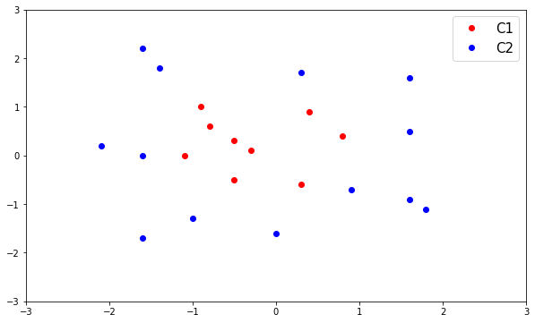

```python
x_c1 = np.array([[-1.1, 0],
                 [-0.3, 0.1],
                 [-0.9, 1],
                 [0.8, 0.4],
                 [0.4, 0.9],
                 [0.3, -0.6],
                 [-0.5, 0.3],
                 [-0.8, 0.6],
                 [-0.5, -0.5]])

x_c2 = np.array([[-1, -1.3],
                 [-1.6, 2.2],
                 [0.9, -0.7],
                 [1.6, 0.5],
                 [1.8, -1.1],
                 [1.6, 1.6],
                 [-1.6, -1.7],
                 [-1.4, 1.8],
                 [1.6, -0.9],
                 [0, -1.6],
                 [0.3, 1.7],
                 [-1.6, 0],
                 [-2.1, 0.2]])

plt.figure(figsize=(10, 6))
plt.plot(x_c1[:,0], x_c1[:,1], 'ro', label='C1')
plt.plot(x_c2[:,0], x_c2[:,1], 'bo', label='C2')
plt.axis([-3, 3, -3, 3])
plt.legend(fontsize=15)
plt.show()
```

$$ x = \begin{bmatrix} x_1 \\ x_2 \end{bmatrix} \quad \Longrightarrow \quad z = \phi(x) = \begin{bmatrix} 1\\ \sqrt{2}x_1\\ \sqrt{2}x_2 \\x_1^2 \\ \sqrt{2}x_1 x_2 \\x_2^2 \end{bmatrix} $$

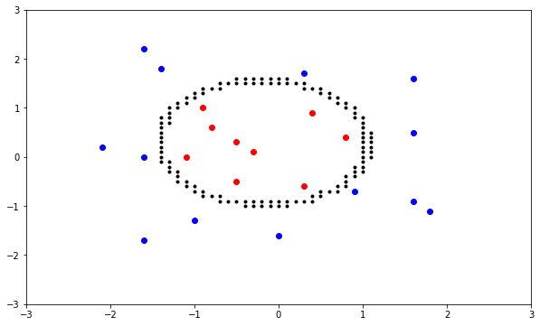

```python
c1n = x_c1.shape[0]
c2n = x_c2.shape[0]

x = np.vstack([x_c1, x_c2])
y = np.vstack([np.ones([c1n, 1]), -np.ones([c2n, 1])])

m = c1n + c2n

x1, x2 = x[:,0].reshape(-1, 1), x[:,1].reshape(-1, 1)
z = np.hstack([np.ones([m, 1]), np.sqrt(2)*x1, np.sqrt(2)*x2, x1**2, np.sqrt(2)*x1*x2, x2**2])
Z = np.asmatrix(z)

g = 1

w = Variable(6, 1)

objective = Minimize(sum_entries(logistic(mul_elemwise(-y, Z*w))))
prob = Problem(objective)
result = prob.solve(solver='SCS')

w = w.value
w = w/np.linalg.norm(w)*10

X1g, X2g = np.meshgrid(np.arange(-3, 3, 0.1), np.arange(-3, 3, 0.1))
X_test = np.vstack([X1g.ravel(), X2g.ravel()]).T
x1t, x2t = X_test[:,0].reshape(-1, 1), X_test[:,1].reshape(-1, 1)
Z_test = np.hstack([np.ones([X_test.shape[0], 1]), np.sqrt(2)*x1t, np.sqrt(2)*x2t, x1t**2, np.sqrt(2)*x1t*x2t, x2t**2])

y_hat = 1/(1 + np.exp(-Z_test*w))

B = []
for i in range(y_hat.shape[0]):
    if np.abs(y_hat[i][0]-0.5) < 0.2:
        B.append(X_test[i,:])
B = np.array(B)

plt.figure(figsize=(10, 6))
plt.plot(x_c1[:,0], x_c1[:,1], 'ro')
plt.plot(x_c2[:,0], x_c2[:,1], 'bo')
plt.plot(B[:,0], B[:,1], 'k.')
plt.axis([-3, 3, -3, 3])
plt.show()
```

- $l_2$ regularized logistic regression
  - non-linear and overfitting
  - make $\omega$ small $$ \begin{align*} \min_{\omega} &\; \lambda \rVert \omega \lVert_2^2 + \sum\limits_{n=1}^{m}{\log \left(1+\exp \left(-y_n\omega^T x_n \right) \right)} \end{align*} $$

Download the data files

- [download nonlinear x](https://www.dropbox.com/s/bsxxcahjm31gv9s/nonlinear_x.dat?dl=0)
- [download nonlinear y](https://www.dropbox.com/s/6939y9e8jm9xp55/nonlinear_y.dat?dl=0)

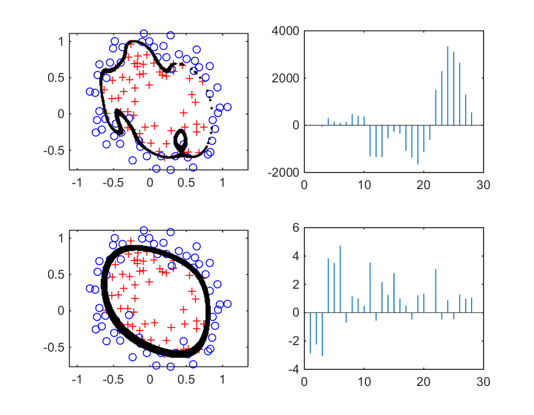

```python
%plot -s 900,700
% source: By Andrew Ng at Stanford Univ.
% http://openclassroom.stanford.edu/MainFolder/DocumentPage.php?course=MachineLearning&doc=exercises/ex5/ex5.html

X = load([pwd,'\image_files\nonlinear_x.dat']);
y = load([pwd,'\image_files\nonlinear_y.dat']);

y(y == 0) = -1;

pos = find(y+1);
neg = find(y-1);
plot(X(pos,1),X(pos,2),'r+',X(neg,1),X(neg,2),'bo')
axis equal

%% estimate w from regularized logistic regression for non-linear data
m = length(y);
d = 6;

% polynomial functions
Z = ones(m,1);
for i = 1:d
    for j = 0:i
        Z = [Z (X(:,1).^(i-j)).*(X(:,2).^j)];
    end
end

n = size(Z,2);

[X1g, X2g] = meshgrid(-3:0.01:3,-3:0.01:3);
X_test = [X1g(:) X2g(:)];

Z_test = ones(length(X_test),1);

for i = 1:d
    for j = 0:i
        Z_test = [Z_test (X_test(:,1).^(i-j)).*(X_test(:,2).^j)];
    end
end

g = [0 1];

for k = 1:length(g)
    clear w
    cvx_begin quiet
        variable w(n,1)
        minimize (g(k)*norm(w,2) + sum(log_sum_exp([zeros(1,m); (y.*(Z*w))'])))
    cvx_end

    y_hat = 1./(1 + exp(-Z_test*w));

    % plotting a decision boundary
    B = [];
    for i = 1:length(y_hat)
        if abs(y_hat(i)-0.5) < 0.1
            B = [B; X_test(i,:)];
        end
    end

    subplot(length(g),2,2*k-1), plot(X(pos,1),X(pos,2),'r+',X(neg,1),X(neg,2),'bo'), hold on
    plot(B(:,1),B(:,2),'k.'),   hold off, axis equal
    subplot(length(g),2,2*k), stem(w,'marker','none')
end
```

- $l_1$ regularized logistic regression
  - nonlinear, overfitting, and too many features
  - make $\omega$ small and sparse $\rightarrow$ feature selection for classification

$$ \begin{align*} \min_{\omega} &\; \lambda \rVert \omega \lVert_1 + \sum\limits_{n=1}^{m}{\log \left(1+\exp \left(-y_n\omega^T x_n \right) \right)} \end{align*} $$

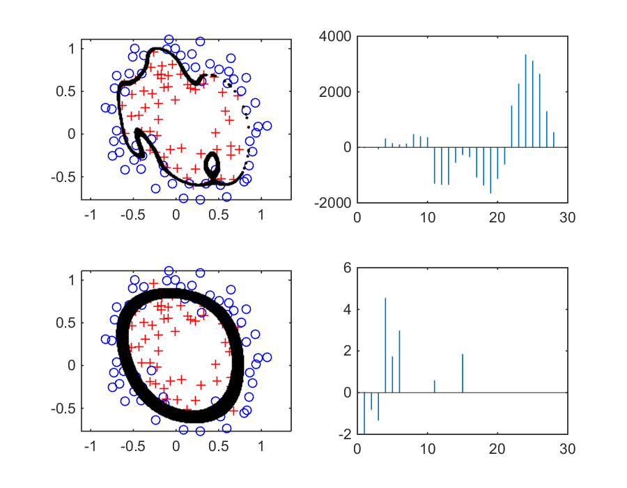

```python
%plot -s 900,700
X = load([pwd,'\image_files\nonlinear_x.dat']);
y = load([pwd,'\image_files\nonlinear_y.dat']);

y(y == 0) = -1;

pos = find(y+1);
neg = find(y-1);
plot(X(pos,1),X(pos,2),'r+',X(neg,1),X(neg,2),'bo')
axis equal

%% estimate w from regularized logistic regression for non-linear data
m = length(y);
d = 6;

% polynomial functions
Z = ones(m,1);
for i = 1:d
    for j = 0:i
        Z = [Z (X(:,1).^(i-j)).*(X(:,2).^j)];
    end
end

n = size(Z,2);

[X1g, X2g] = meshgrid(-3:0.01:3,-3:0.01:3);
X_test = [X1g(:) X2g(:)];

Z_test = ones(length(X_test),1);

for i = 1:d
    for j = 0:i
        Z_test = [Z_test (X_test(:,1).^(i-j)).*(X_test(:,2).^j)];
    end
end

g = [0 1];

for k = 1:length(g)
    clear w
    cvx_begin quiet
        variable w(n,1)
        minimize (g(k)*norm(w,1) + sum(log_sum_exp([zeros(1,m); (y.*(Z*w))'])))
    cvx_end

    y_hat = 1./(1 + exp(-Z_test*w));

    % plotting a decision boundary
    B = [];
    for i = 1:length(y_hat)
        if abs(y_hat(i)-0.5) < 0.1
            B = [B; X_test(i,:)];
        end
    end

    subplot(length(g),2,2*k-1), plot(X(pos,1),X(pos,2),'r+',X(neg,1),X(neg,2),'bo'), hold on
    plot(B(:,1),B(:,2),'k.'),   hold off, axis equal
    subplot(length(g),2,2*k), stem(w,'marker','none')
end
```

## 4.2. Implicit Feature Vector (Kernel)

```python
%%javascript
$.getScript('https://kmahelona.github.io/ipython_notebook_goodies/ipython_notebook_toc.js')
```